# Annual review

Thomas Wright

**To this point**:

- Extension of bond-calculus: process algebra with:
  - Continuous and stochastic semantics.
  - Functional rates via *affinity patterns*.
- Paper (SASB 2018) modelling gene regulation at network and molecular levels.
- Technical paper presenting core language and continuous semantics (currently on ArXiV).

**Ongoing**:

- Focus on extending ${\mathcal{L}\mathcal{BC}}$ using techniques from Hybrid Automata reachability analysis (flow*).
- **Overall aim**:
  - Investigate integration of Taylor model flowpipe construction with temporal logic to model check contextual properties.
- **General approach**
  - Signal monitoring over flow* flowpipes (with three-valued signals).
- **Some challenges**:
  - *Uncertain contextual properties*: $$([a, b]\,X \mathrel\parallel [c,d]\,Y) \triangleright \varphi$$
  - *Differential contexts*: $$([a, b]\,X \mathrel\parallel [c,d]\,Y) \triangleright_{\partial} \varphi$$
  - *More general constrained contexts*: $$([a,b]\,X \parallel [c,d]\,Y : \psi) \triangleright \varphi$$

## Current progress

- Implementing three-valued signals (using Python)
- Signal monitoring over flowpipes (using interval Newton-Raphson iteration)
- Wrapping flow* C++ API (using Cython)
- Methods for model checking context operators

## A simple example:

| ODE: | System: |
| --- | --- |
| $\frac{\mathrm d [\mathrm{X}]}{\mathrm dt} = - [\mathrm{Y}]$ | $\mathrm X \triangleq x.(X\|Y)\qquad\mathrm{Y}\triangleq y.(Y\|X)$ |
| $\frac{\mathrm d [\mathrm{Y}]}{\mathrm dt} = [\mathrm{X}]$ |  |

Initial condition: $[\mathrm X]_0 \in [4,5],\; [\mathrm Y]_0 \in [1,2]$

$X(t)$ flowpipe:

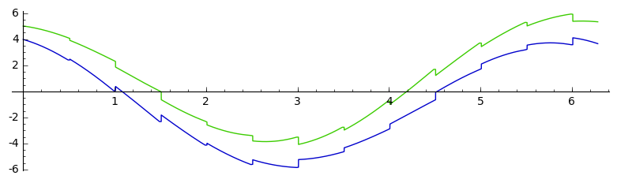

$Y(t)$ flowpipe:

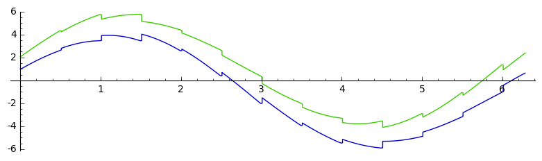

$X(t), Y(t)$ octogons:

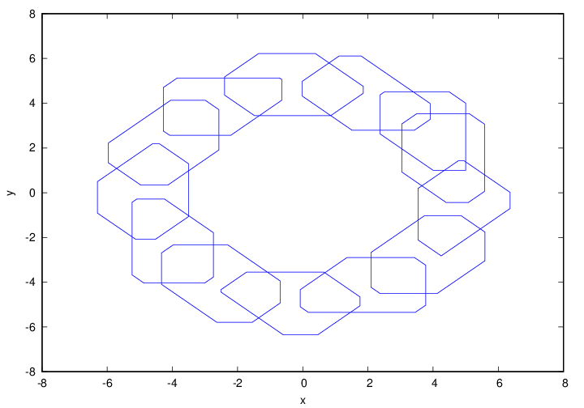

**Goal**: Does this system satisfy a spatio-temporal formulae e.g.

$$ \mathbf F_{[\pi/6,\pi/2]}([X] > 0 \Rightarrow [9,10]\,Y \triangleright \mathbf G_{[0,\pi/2]}([Y] > 0))$$

**Approach**:

- Use flow* as a backend to extract Taylor model flowpipes: $$(p_1(\mathbf x,t), I_1),\; \ldots,\; (p_n(\mathbf x,t), I_n)$$ enclosing evolution of system.
- Build three-valued temporal signals $\varphi : \mathbb R_{\geq 0} \to \{\texttt{True}, \texttt{False}, \bot\}$ for satisfaction of temporal formulae.
  - Find signals for atomic propositions using root detection.
  - Combine signals for more complex propositions.

Context operators are more complex and will require multiple calls to flow*.

### How to call flow*?

Flow* usually runs from the command line and dumps flowpipes to disk.

Instead we directly link to Flow*'s C++ API:

- Flowpipes stored in memory
- Can directly query them via Flow*'s API

Flow* wrapped in python $\texttt{Reach}$ class (via Cython):

```python
variables = ['x', 'y']
odes      = [Poly(-1, 'y', 1, variables), Poly(1, 'x', 1, variables)]

C0 = Reach(
    variables,       # List of variables
    odes,            # ODEs
    [(4,5), (1,2)],  # Initial conditions
    2*pi,            # Time horizon
    0.5,             # Step size
    order=10,        # Taylor model order
)
```

This allows us to do interval evaluation:

```python
(x, y) = C0((1,2))
```

```
t in [1.0000000000000000 .. 2.0000000000000000]
x in [-4.2765158639230583 .. 2.2878179688425995]
y in [2.5635778686684003 .. 6.2179798266784046]
```

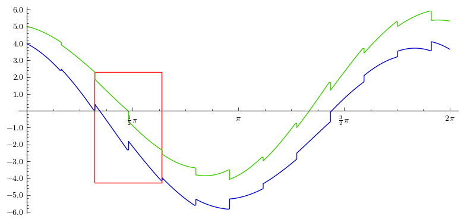

## Three-valued signal monitoring

We want to extract a three-valued signal $$\varphi : \mathbb R_{\geq 0} \to \{ \texttt{True}, \texttt{False}, \bot \}$$ of a temporal logic formula over a Taylor model.

For atomic propositions $$\varphi \triangleq g(\mathbf x) > 0$$ we use Interval-Newton iteration [1].

1. Ishii, D., Yonezaki, N., Goldsztejn, A.: Monitoring Temporal Properties using Interval Analysis. IEICE Transactions on Fundamentals of Electronics, Communications and Computer Sciences E99-A (2016)

### Method

- Isolate roots of $f(t) = g(x(t))$ using extended Inteval-Newton iteration (extending [1]):
  - Start with whole interval $I_0 = [l_0, u_0]$
  - Iterate $$ I_{k+1} := \left(l_k - \frac{f(l_k)}{f(I_k)} \right) \cap I_k $$ to find lower bound.
  - Find some $u_k > l_k$ past the root
  - Iterate $$ I_{k+1} := \left(u_k - \frac{f(u_k)}{f(I_k)} \right) \cap I_k $$ to find upper bound.
- Construct signal by checking values in between roots.

### Guarentees

- Guarentees correctness of signal values in between roots.
- All roots contained in uncertain intervals (but not necessarily a unique root).
- Flow* handles different sources of uncertainty:
  - Uncertain initial conditions
  - Uncertain time of context application
  - Numerical error
  - Uncertain rates
- Truely dense time: Taylor Models enclose the behaviour in between steps.

$$ P \triangleq [\mathrm X] > 3$$

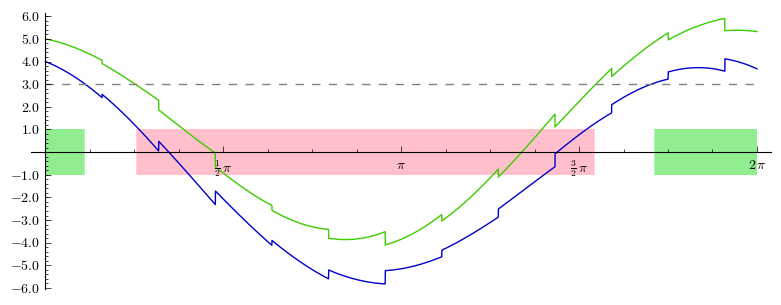

$$Q \triangleq [Y] < 3$$

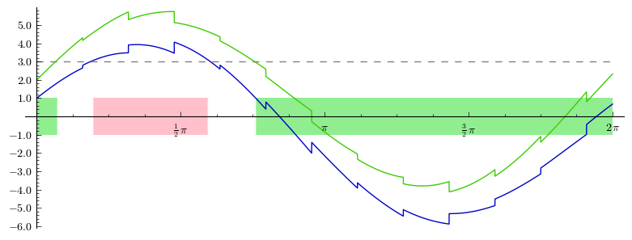

$$\mathrel{\mathbf G}_{[1,1.2]} ([X] > 3)$$

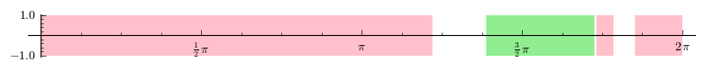

```python
plot_signal( P.G(RIF(1,1.2)) )
```

$$\mathrel{\mathbf F}_{[3.5,4]} ([Y] < 3)$$

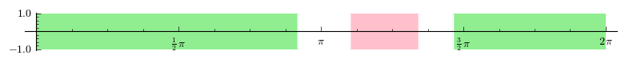

```python
plot_signal( Q.F(RIF(3.5,4)) )
```

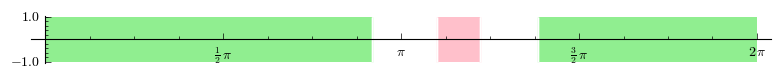

```python
plot_signal( P.G(RIF(1,1.2)) | Q.F(RIF(3.5,4)) )
```

$$\mathrel{\mathbf G}_{[1,1.2]} ([X] > 3) \wedge \mathrel{\mathbf F}_{[3.5,4]} ([Y] < 3)$$

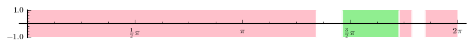

```python
plot_signal( P.G(RIF(1,1.2)) & Q.F(RIF(3.5,4)) )
```

$$(\mathrel{\mathbf G}_{[1,1.2]} ([X] > 3)) \mathrel{\mathbf U_{[0.4,0.5]}} (\mathrel{\mathbf F}_{[3.5,4]} ([Y] < 3))$$

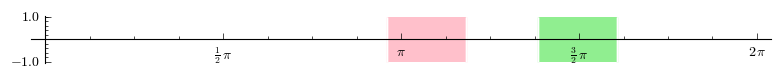

```python
plot_signal( P.G(RIF(1,1.2)).U(RIF(0.4,0.5), Q.F(RIF(3.5,4))) )
```

## Monitoring context signal

A context operator specifies behaviour after adding a new (uncertain) process: $$[9,10]\,Y \triangleright \mathbf G_{[0,\pi/2]}([Y] > 0)$$

Applies a jump to the current state and then checks the new system:

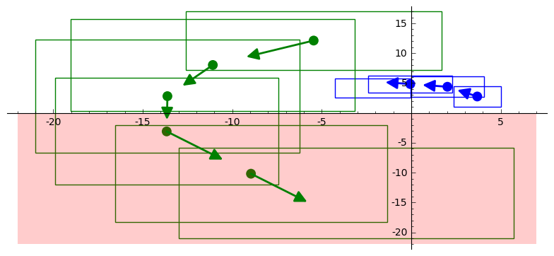

Signal of $[9,10]\,Y \triangleright \mathbf G_{[0,\pi/2]}([Y] > 0)$:

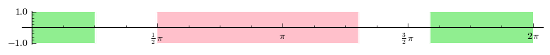

Current method: subdivide time, and monitor signal for composed system on each interval.

Can then check further temporal properties: $$\mathbf F_{[\pi/6,\pi/2]}([X] > 0 \Rightarrow [9,10]\,Y \triangleright \mathbf G_{[0,\pi/2]}([Y] > 0))$$

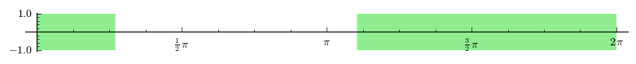

```python
plot_signal( (~sigx | sig).F(RIF(pi/6,pi/2)) )
```

### Improving accuracy

One approach: subdivide context e.g.

$$[9,10]\,Y \triangleright \mathbf G_{[0,\pi/2]}([Y] > 0)$$ becomes $$ ([9,9.5]\,Y \triangleright \mathbf G_{[0,\pi/2]}([Y] > 0)) \wedge ([9.5,10]\,Y \triangleright \mathbf G_{[0,\pi/2]}([Y] > 0)) $$

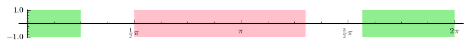

Effective, but rather costly. Can we do better?

**A problem**: $$[X] > 0 \Rightarrow [9,10]\,Y \triangleright \mathbf G_{[0,\pi/2]}([Y] > 0)$$

Current methods check propositions $$[X] > 0$$ and $$[9,10]\,Y \triangleright \mathbf G_{[0,\pi/2]}([Y] > 0)$$ independantly, whilst the constraint should rule out most of the initial set.

Idea: apply state constraints to restrict initial set (similar to HA guard intersection).

## Monitoring differential contexts

$$[0.1,0.2]\,Y \triangleright_{\partial} \mathbf G_{[0,\pi/2]}([Y] > 0)$$

**Semantics**: add $Y$ at rate $r \in [0.1, 0.2]$

**Proposed method**: After jump set $$\begin{bmatrix}\mathrm d[X]/\mathrm dt \\ \mathrm d [Y]/\mathrm d t\end{bmatrix} = \begin{bmatrix} -[Y] \\ [X] + [0.1, 0.2] \end{bmatrix}$$

Very similar to uncertain contexts, but add uncertain input to ODEs.

Flow* can handle these via Taylor models with symbolic remainders (at the cost of more bloating of flowpipes).

## Monitoring general bounded contexts

Can we use general temporal properties as constraints on contexts? $$([a,b]\,X \parallel [c,d]\,Y : \psi) \triangleright \varphi$$

**Semantics**: $\varphi$ in any context with bounded concentrations $X \in [a,b], Y \in [c, d]$ which satisfies $\psi$.

This give the bounded space version of Ambient Logic's *guarantee* operator.

**Approach**: subdivide context into boxes $Q = [a', b'] X \parallel [c', d'] Y$ and check $$ Q \models \psi \implies P \parallel Q \models \varphi $$

[figure not shown]

How scalable is this?

### Next steps

- Apply to more interesting examples and benchmark performance.
- Continue implementation and formalise semantics.
- Handling of $\Rightarrow$.
- Improve adaptiveness.
- Differential and general bounded contexts.

### Extensions

- Quantitative degree of satisfaction?
- Combine with discrepancy functions?
- Decomposition of system?